# Lecture 15：Dynamic pricing

企業の動学的価格設定・コース総括｜計量経済学II

Kei Ikegami

## 今日の流れ（90分）

| 時間 | 内容 |
| --- | --- |
| 10分 | 復習クイズ |
| 8分 | 個人への施策から、時間を通じた価格設定へ |
| 7分 | 静学的な価格の復習 |
| 15分 | 消費者の値下げ待ちと企業の価格案 |
| 25分 | 在庫と販売期限を持つ企業の問題 |
| 15分 | 需要の推定誤差と収益 |
| 10分 | 講義全体のつながり・まとめ |

ピーク時料金とサージ価格は補足資料。

## Quiz（前回の復習・10分）

- 配布した Quiz 15 に解答する（**5分**、メモ・ノート参照可）
- そのあと解説（**5分**）
- 採点はしない。前回の内容のセルフチェックとして使うこと

# 導入：「dynamic」の交通整理

## 前回とのつながり

- 第10回：個人別需要からクーポンを選ぶ
- 第11回：将来購買と長期の顧客価値を予測する
- 第13〜14回：先読み、状態依存、買いだめを考える
- 今回：消費者の将来の反応と、企業自身の在庫・期限を踏まえて価格を選ぶ

## 今日押さえたいこと

1. 「dynamic pricing」という言葉に混ざっている**3つの別物**を交通整理できる
2. 静学の**逆弾力性ルール**を出発点に、RMでは在庫の機会費用がどう加わるかを確認する
3. 第13回の無限期間の価値関数反復と区別し、有限期間のrevenue managementを**終端から後ろ向きに解く**
4. surge pricing が需給反応と摩擦を通じて「**市場を回す**」役割を持ち得ることと、その大きさは実証問題であることを理解する
5. 需要推定×因果推論×異質性×動学が「**価格を賢く決める**」という1つの課題に収束することを確認する

## 価格を変える3つの話を区別する

1. **時間帯・需給**で価格が変わる：電気のピーク課金、ライドシェアのサージ、深夜タクシー
2. **販売期限と在庫**で価格が変わる：航空券・ホテル。revenue management（RM）の領域
3. **顧客ごと**に価格が変わる：会員ランク割引、履歴ベースのクーポン・パーソナライズ価格
- (1)(2)は「同じ商品を同じ客に、状況に応じて違う価格で」
- (3)は「同じ状況で、違う客に違う価格で」
- この講義では (1)(2) を **dynamic pricing**、(3) を **personalized pricing** と呼び分ける

## この講義での定義

**企業の価格「ルール」が、時間・在庫・市場需要などの運用状態の関数になっている。** これを dynamic pricing と呼ぶ。顧客の属性・履歴に応じる personalized pricing は隣接領域だが別概念。

- 第13回の言葉で言えば：状態 $x$ を見て行動（価格）を決める**政策関数**を設計する問題
- 両者を組み合わせることはできるが、必要な識別・モデル・リスクは同じではない

## ビジネスの現場で：「うちも導入しよう」と言われたら

経営会議で「競合がAIで価格を変えているらしい。うちも」という話が出たら、最初にすべき質問：

> それは (1)(2)(3) の**どれ**の話ですか？
- 閑散期・繁忙期で変えたい → (1)(2)：今日学ぶ在庫・時間の状態管理
- 優良顧客とライトユーザーで変えたい → (3)：personalized pricing
- 必要な識別・モデルと、公平性・炎上リスクの論点も異なる

**ノート**

二値・少数の離散armなら、各armの効果を識別できる実験とoverlapのもとでCATE / policy learningを使える場合がある。連続・多値価格には、需要曲線・dose-response・choice model、価格のsupport / overlap、対応するpolicy learningが必要。

# 静学ベンチマーク：逆弾力性ルール

## すべての出発点：独占企業の価格づけ

需要量 $q(p)$、限界費用 $mc$ の独占企業の利潤：

$$\pi(p) = (p - mc) \, q(p)$$

一階条件を整理すると**逆弾力性ルール**（Lerner指数）：

$$\frac{p - mc}{p} = \frac{1}{|\eta(p)|}$$

マージン率は弾力性の逆数で決まる。

## logit需要のもとでの利潤

財1つ（買う／買わない、outsideが $j=0$）。条件付き購買確率を $s(p)$ と書く：

$$s(p) = \frac{\exp(\theta_0 - \alpha p)}{1 + \exp(\theta_0 - \alpha p)}$$

一定の限界費用 $mc$ のもとで、1人あたり期待利潤は

$$\pi(p) = s(p)(p-mc)$$

## 利潤カーブと最適価格

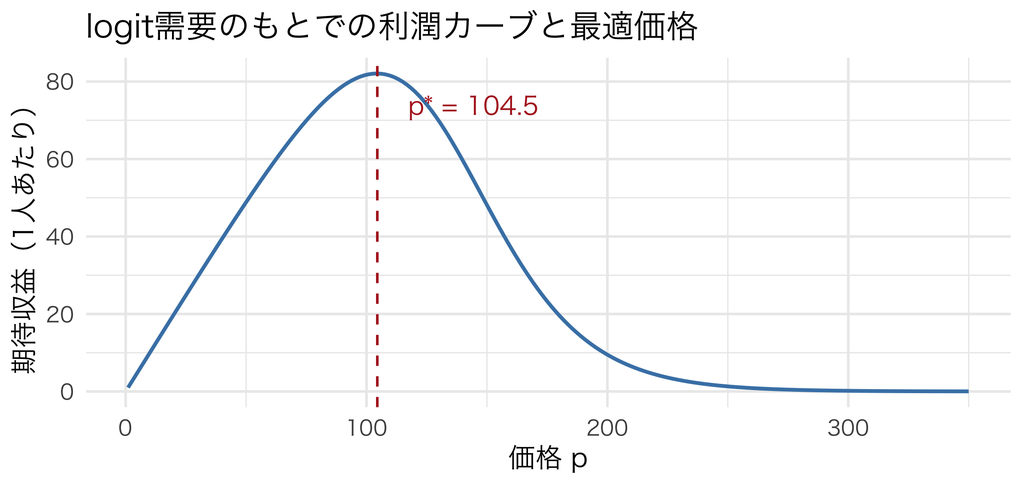

図 1

- この単一商品・二値logit・一定限界費用の例では山が1つ。これはロジット**対数尤度**の凹性とは別の主張であり、複数商品や非線形費用では利潤が大域的に凹とは限らない。

## 一階条件は固定点方程式

微分してゼロと置くと（導出はノートの折りたたみcallout）：

$$p^* = mc + \frac{1}{\alpha\{1-s(p^*)\}}$$

- $p^*$ が両辺にある固定点。**この単一商品・二値logit・一定 $mc$ という仕様に限れば** Lambert $W$ で閉形式にもできる：

$$p^*=mc+\frac{1+W\!\left(\exp(\theta_0-\alpha mc-1)\right)}{\alpha}.$$

- 本講義では、特殊関数に頼らず利潤を数値的に最大化する。

静学の教訓：価格を決めるには、価格に対する需要の反応と費用が必要である。$\alpha$ は価格係数であり、弾力性そのものではない。後の在庫モデルでは、ここに在庫を残す機会費用が加わる。

# 消費者が値下げを待つときの価格設定

## 今買うか、待つか

- 評価額$v_i$は0〜20千円の一様分布。一人1本、在庫は十分ある
- 企業は$p_1,p_2$を最初に公表し、その価格を守る
- 消費者の選択：$\max\{v_i-p_1,\;0.8(v_i-p_2),\;0\}$
- 企業の利益：$p_1P(\text{今買う})+p_2P(\text{後で買う})$

現在の需要は、将来の価格にも依存する。

## 価格案を同じ消費者に対して評価する

すべての価格案を、将来の価格を知っている同じ消費者に対して評価する（価格・利益：千円）

| 価格の選び方 | 1期目価格 | 2期目価格 | 1期目購入率 | 2期目購入率 | 顧客1人あたり利益 |
| --- | --- | --- | --- | --- | --- |
| 同じ価格を維持 | 10.00 | 10.00 | 0.500 | 0.000 | 5.000 |
| 待機を無視して選ぶ | 13.25 | 6.75 | 0.000 | 0.663 | 4.473 |
| 待機を考慮して選ぶ | 10.50 | 9.50 | 0.275 | 0.250 | 5.263 |

## 待機を考慮した利益

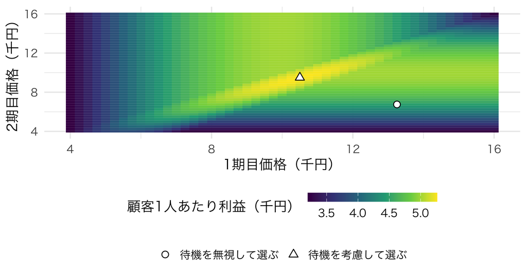

図 2: 将来の値下げを待つ消費者に対する利益。候補価格は0.25千円刻み。

# Revenue management

## 設定：航空券1路線

- 残り日数 $t$（$t=T$ が今日、$t=0$ が出発日＝販売終了）
- 残り座席数 $c$（$c=0$ なら完売）
- 毎期、確率 $\bar\lambda$ で1人の客が到着。到着した客はロジットで購買を決める

$$\lambda(p) = \bar\lambda \cdot \frac{\exp(\theta_0 - \alpha p)}{1 + \exp(\theta_0 - \alpha p)}$$

- 「客が来るか」と「来た客が買うか」を分けるのは実務データとの対応（訪問数×訪問あたり購買率）

## Bellman方程式

$$V(t, c) = \max_{p} \left( \lambda(p) \left[ p + V(t-1, c-1) \right] + (1 - \lambda(p)) \, V(t-1, c) \right)$$

| 今期の事象 | 確率 | 今期収入 | 次期の状態 | 継続価値 |
| --- | --- | --- | --- | --- |
| 売れる | $\lambda(p)$ | $p$ | $(t-1,c-1)$ | $V(t-1,c-1)$ |
| 売れない | $1-\lambda(p)$ | $0$ | $(t-1,c)$ | $V(t-1,c)$ |

- 各枝で「確率 ×（今期収入＋継続価値）」を作り、2枝を足してから $p$ で最大化する。
- 境界条件は2つ：
  - 在庫が尽きたら以後の収益ゼロ（$V(t, 0) = 0$）
  - 期限が来たら以後の収益ゼロ（$V(0, c) = 0$）

## 第13回との対応・記法の断り

| 第13回（Rustのバス） | 今日（航空券RM） |
| --- | --- |
| 状態：走行距離 | 状態：残り期間と残り座席の組 |
| 行動：交換する／しない | 行動：今日の価格 |
| 無限期間：価値関数反復 | 有限期間：終端からのbackward induction |

- 割引因子 $\beta$：今日は販売期間が数十日と短いので、実質 $\beta = 1$（将来の座席の価値を割り引かない）で解く
- 効用パラメータは $\theta$、価格係数は $\alpha$（第2回以来の記法）

## Rで解く（1）：パラメータと購買確率

```r
theta0     <- 6.0     # 価格ゼロでの基準効用
alpha      <- 0.045   # 価格係数（第2回以来の記法、alpha > 0）
lambda_bar <- 0.95    # 1期あたりの客の到着確率
T_period   <- 60      # 販売期間（残り日数の最大値）
C_capacity <- 30      # 座席数

p_grid <- seq(1, 350, length.out = 150)

purchase_prob <- function(p, theta0, alpha, lambda_bar) {
  u <- theta0 - alpha * p
  lambda_bar * (1 / (1 + exp(-u)))
}
```

60日で30席を売り切りたい航空会社、というイメージ。

## Rで解く（2）：backward induction

```r
solve_dp <- function(T_period, C_capacity, theta0, alpha, lambda_bar, p_grid) {
  # 行 t+1 が状態t、列 c+1 が状態c（Rは1始まり、DPの状態は0始まり）
  V       <- matrix(0, nrow = T_period + 1, ncol = C_capacity + 1)
  pstar   <- matrix(NA_real_, nrow = T_period + 1, ncol = C_capacity + 1)
  lamstar <- matrix(0, nrow = T_period + 1, ncol = C_capacity + 1)
  lam_grid <- purchase_prob(p_grid, theta0, alpha, lambda_bar)
  for (t in 1:T_period) {
    for (c in 1:C_capacity) {
      # V[t, c] = V(t-1, c-1)（購入時）、V[t, c + 1] = V(t-1, c)（非購入時）
      obj <- lam_grid * (p_grid + V[t, c]) + (1 - lam_grid) * V[t, c + 1]
      best <- which.max(obj)
      V[t + 1, c + 1]       <- obj[best]
      pstar[t + 1, c + 1]   <- p_grid[best]
      lamstar[t + 1, c + 1] <- lam_grid[best]
    }
    V[t + 1, 1] <- 0   # 在庫ゼロなら収益なし
  }
  list(V = V, pstar = pstar, lamstar = lamstar)
}
```

Rの1始まり索引とDPの0始まり状態のズレに注意。`V[t, c]`・`V[t, c + 1]`・`V[t + 1, c + 1]` という3つの似た添字は**バグではなく対応規則**。添字を書くたびに「数式のどの状態か」を確認すること（ノートのcallout参照）。

## 解けた：状態ごとの最適価格

backward inductionが返す最適価格（期待総収益 V(T,C)=3833）

| 状態（残り期間・残り座席） | 最適価格 |
| --- | --- |
| 残り60日・残り30席（初日・満席） | 129.8 |
| 残り60日・残り1席 | 221.2 |
| 出発前日・残り30席（全然売れていない） | 104.1 |
| 出発前日・残り1席 | 104.1 |

- 同じ「残り60日」でも、席が残り1つなら価格は大きく跳ね上がる
- 同じ「満席のまま」でも、出発前日なら価格を下げて売り切りにいく

## 最適価格ヒートマップ

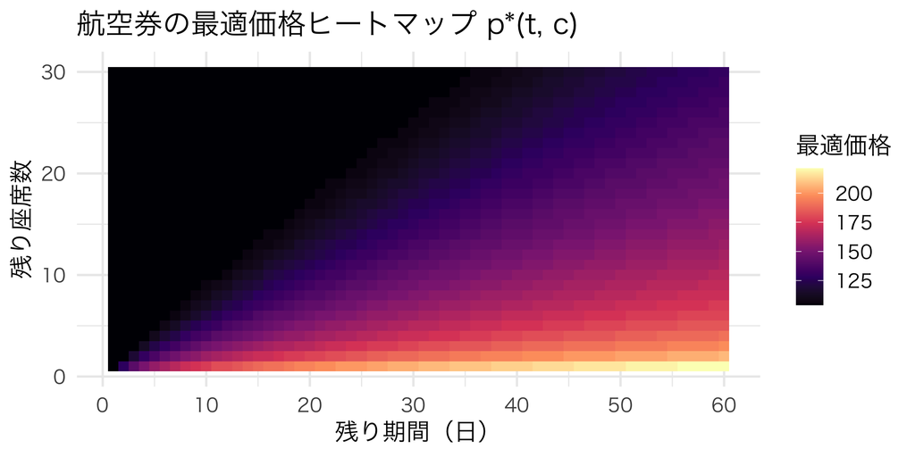

図 3

- 明るい（高価格）：残り期間が長く在庫が少ない領域。暗い（低価格）：期限間近で在庫が潤沢な領域
- 「期限」と「在庫」という**2つの希少性の圧力**が価格に変換されている

## bid price：席1つの機会費用

RM実務の中心概念。「状態 $(t,c)$ で座席を1つ**今売る**ことの機会費用」：

$$b(t,c)=V(t-1,c)-V(t-1,c-1)$$

- 売らない枝は次期 $(t-1,c)$、売る枝は次期 $(t-1,c-1)$。その継続価値の差を取る。
- $V(t,c)-V(t,c-1)$ は「同じ期首で追加1席を持つ価値」であり、今期の販売FOCへ直接入るbid priceとは別。

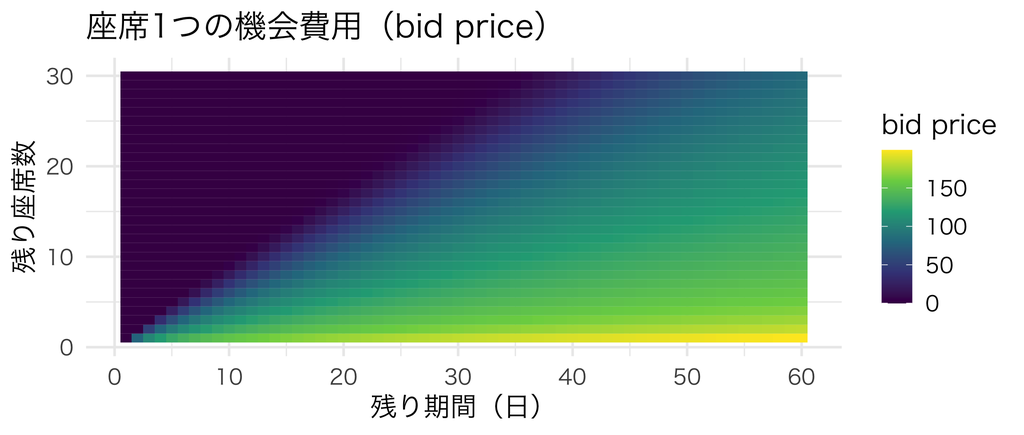

図 4

条件付き購買確率を $s(p)$ とすれば、内部解のFOCは

$$p^*(t,c)=b(t,c)+\frac{1}{\alpha\{1-s(p^*(t,c))\}}.$$

bid priceを限界費用の位置へ入れた**新しい固定点**であり、「静学最適価格＋bid price」という単純な足し算ではない。

## 価格ルールを動かす：予約パスのシミュレーション

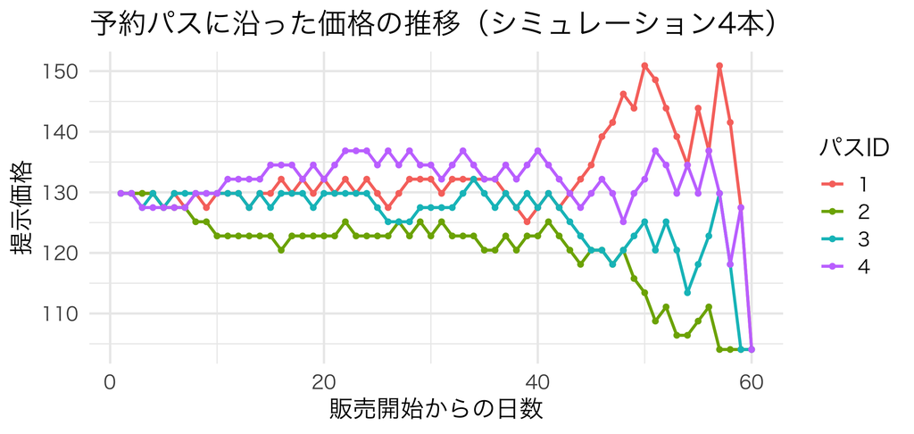

図 5

- **同じ価格ルール**から出発しても、需要の実現次第で価格の軌道は変わる
- ブッキングカーブを眺めながら日々価格を微調整する、RM実務の日常の姿

## 動的価格は固定価格よりどれだけ得か

固定価格 vs 動的価格の期待収益比較

| 方式 | 価格の目安 | 期待収益 |
| --- | --- | --- |
| 最適固定価格 | 129.1 | 3742.6 |
| 動的価格（DP最適） | 状態に応じて変動 | 3833.0 |

```
動的価格による収益リフト: 2.41 %
```

このrenderでのリフトは **2.41%**。これは現在のパラメータと価格グリッドで再計算した値で、一般に固定された数字ではない。

## なぜリフトは「意外と小さい」のか

- Gallego and van Ryzin (1994)：一般需要について決定論的問題から収益上界を作り、期待販売量が大きくなる極限で単純な固定価格政策が漸近最適になることを証明
- 動的価格が本当に光るのは：
  - 需要の**不確実性**が大きいとき
  - 在庫が需要に対して**極端に逼迫・過剰**で、実現した売れ行きへの適応価値が大きいとき

「うちの事業にRMを入れる価値があるか」の判断軸は、**需要の変動性**と**在庫の逼迫度**。この2つが穏やかなら、良い固定価格で十分なことも多い。

## 実証研究コーナー：Williams (2022)

- **問い**：航空会社の動的価格は、需要ショックと到着時点によるWTP変化を通じて厚生をどう変えるか
- **データ・戦略**：flight-level dataで両方の価格調整源を含むモデルを推定し、期間中の価格を一律にする反実仮想と比較
- **発見**：一律価格との比較で、動的価格は早く到着するレジャー客を利し、遅く到着するビジネス客には座席を残す一方で高価格を課す。市場を集計すると厚生は高いが、個別市場での符号は価格変動の源泉に依存

第10回の個人別需要×今日の「いつ・どの状態で」を組み合わせると、「誰が得をして誰が損をするか」まで問える。

# 推定から最適化へ

## パイプライン：需要推定の誤差はどこへ行くか

コース前半（需要推定）と今日（最適化）を1本につなぐ：

1. 真の $(\theta_0,\alpha)$ から生成された予約データで、$(\hat\theta_0,\hat\alpha)$ を**最尤推定**（第2回の再演）
2. $(\hat\theta_0,\hat\alpha)$ を真値だと思い込んで、backward inductionで価格政策 $\hat p^*(t,c)$ を作る
3. その政策を**真のモデル**の上で走らせ、期待収益を評価する

**需要推定の誤差は、消えてなくなるのではなく、価格政策の収益ロスという「金額」に変換される。**

## Step 1：価格実験データからMLE

複数の価格水準をランダムに割り当てた予約データ（1シーズン分）から、ロジットを自作ニュートン法で推定する。

```r
mle_result <- fit_logit_newton(booking_data$prices, booking_data$purchase)
const_hat <- mle_result$theta[1]
alpha_hat <- mle_result$theta[2]
cat("真の (theta0, alpha):", theta0, alpha, "\n")
```

```
真の (theta0, alpha): 6 0.045
```

```r
cat("推定 (theta0_hat, alpha_hat):", round(const_hat, 3), round(alpha_hat, 4), "\n")
```

```
推定 (theta0_hat, alpha_hat): 9.213 0.0677
```

- データは1シーズン分（数十観測）しかない → $(\hat\theta_0,\hat\alpha)$ の双方に推定誤差が乗る

## Step 2-3：推定政策を真のモデルで評価

推定誤差が生む収益ロス

| 政策 | 真のモデル上での期待収益 |
| --- | --- |
| 真の需要パラメータで作った政策 | 3833.0 |
| 推定需要パラメータで作った政策 | 3821.7 |

```
収益ロス: 11.3 （真の収益の 0.29 %）
```

- $(\hat\theta_0,\hat\alpha)$ がずれる → 政策 $\hat p^*(t,c)$ がずれる → 収益が目減りする
- ただし1回だけでは「たまたま」かもしれない → モンテカルロへ

## モンテカルロ：誤差の分布が収益ロスの分布に変わる

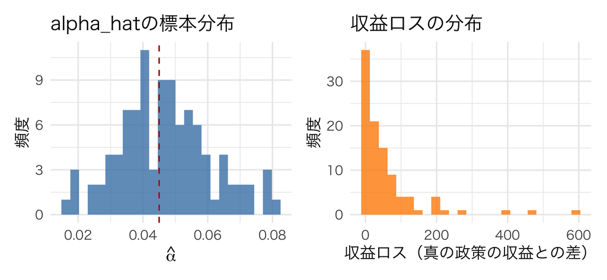

図 6

- $(\hat\theta_0,\hat\alpha)$ の同時推定誤差が、DPを通じて収益ロスへ**非線形に変換**される
- 左の $\hat\alpha$ は同時分布の一つの周辺分布であり、右図と一対一対応するわけではない
- 右の分布は右に長い裾：たいていはそこそこ、**稀に推定が大きく外れると収益が大きく毀損**

## 本当に内生な価格DGP：企業だけが見る需要ショック

価格の支持が狭いだけでは「識別が弱い」のであって、価格内生性とは限らない。内生性を作るには、企業は見るが分析者は省略する持続的需要ショック $\xi_{s,t}$ を価格政策と需要の両方へ入れる：

$$\xi_{s,t}=\rho\xi_{s,t+1}+\nu_{s,t},\qquad
p_{s,t}=p^*(t,c)+\gamma\xi_{s,t},\qquad
\Pr(y_{s,t}=1)=\Lambda(\theta_0+\xi_{s,t}-\alpha p_{s,t}).$$

内生性を作るのは価格と欠落需要ショックの相関

| データ | 推定alpha | cor(price, xi) |
| --- | --- | --- |
| 企業がxiを見て価格設定（分析者はxiを欠落） | -0.0007 | 0.7072 |
| 価格をxiと独立にランダム割当 | 0.0395 | 0.0015 |
| 真値 | 0.0450 | 0.0000 |

観察価格では高需要時に企業が値上げするので、価格と省略された $\xi$ が正に相関する。実験的なランダム割当はこの相関を切る。ただし、$\xi$ を省略したpooled logitは非線形の混合モデルなので、ランダム化しても構造パラメータ $\alpha$ と有限標本で完全一致するとは限らない。

## 推定・推論の質は、そのままお金に変わる

- 需要推定の誤差 → 動的計画法を通って → **収益ロスという金額**に変換される
- 企業が観測する需要ショックを省略したまま、その価格政策が生んだデータで再推定すると、**価格内生性**が生じうる
- だから：需要推定（第2〜4回）・属性・施策のランダム化（第7・10回）・実験の設計は、「教科書の作法」ではなく**損益に直結する投資**である

# コース総括：15回の地図

## 市場全体の需要から個人への施策へ

| 回 | 中心となる問い |
| --- | --- |
| 2〜4 | 異質性を集計した需要は、合併や費用変化にどう反応するか |
| 6〜7 | 購買履歴や選択課題から、個人について何が分かるか |
| 8〜9 | 母集団と個人の情報を組み合わせて、どう予測するか |
| 10 | その人への施策で、利益はどれだけ増えるか |
| 11 | 将来購買と長期の価値をどう予測するか |

## 時間を通じた意思決定へ

- 第13回：消費者自身が将来を考えて選ぶ
- 第14回：固定的な好みと状態依存を区別し、買いだめを考える
- 第15回：消費者の待機と企業の在庫・期限を踏まえて価格を選ぶ

何を変え、何を固定する反実仮想なのかを明確にしてから、モデルを使って行動と利益を計算する。

## これからの論点：アルゴリズム価格と協調

- Calvano, Calzolari, Denicolò and Pastorello (2020, AER)：反復価格競争の**シミュレーション環境**で、独立に学習するQ-learning agentsが競争価格を上回る戦略を学ぶ
- 明示的な連絡がない学習結果へ、競争法のagreement／concerted action概念をどう適用するかという論点を提起
- 今日の単一企業RMのDP自体が協調を生むわけではない。複数企業が相互反応を学習する別モデルで初めて出る問題

## 計量経済学IIの哲学

> モデルを書けばシミュレーションできる。シミュレーションできれば、推定量の性質を実験で確かめられる。
- logit需要 → IV → 階層モデル → 動的計画法と、道具は次々に難しくなった
- しかし「まず手を動かしてデータを作り、自分の推定量にかけてみる」という型は**一度も変わらなかった**
- 新しい手法に出会うたびに、この型はこれからも使える

# まとめ

## この回の要点

- dynamic pricing = 価格**ルール**が時間・需給／期限・在庫などの運用状態の関数。顧客履歴に応じる personalized pricing は隣接する別概念
- 第13回は無限期間の価値関数反復、今回は有限期間なので終端から後ろ向きに解く。この在庫モデルでは、席数と残り期間に応じた価格政策が得られる
- bid price $=V(t-1,c)-V(t-1,c-1)$ は今売る機会費用。logitの内部解は $p=b+1/[\alpha(1-s(p))]$
- 動的価格のリフトは意外と小さいこともある。判断軸は**需要の変動性と在庫の逼迫度**
- surgeは需要抑制・供給喚起・摩擦緩和を通じて市場を「回す」役割を持ち得る（大きさと厚生は実証問題）
- 推定誤差は収益ロスという金額に変換される。企業だけが見る需要ショックが価格にも入れば**価格内生性**が生じる

## 宿題

- ヒートマップのコードで `lambda_bar` を0.95から0.5まで下げて、色の分布がどう変わるか確認する。需要が弱くなると動的価格の効果はどうなるか
- 身近なサービス（航空券、ホテル、EC、配車）の価格が「いつ・どんな条件で」動いているか、生成AIに「どんな状態変数に反応していそうか」と聞き、今日の(1)(2)(3)に当てはめてみる
- **coding課題は `assignment15.qmd`**（このコース最後の課題）：予約データの生成→backward induction→推定誤差と収益ロスのモンテカルロ

## 最後に：期末レポートとこの先へ

- 期末レポート（research proposal）のヒント：「需要推定→因果推論→異質性→動学」のどれかを深掘りするだけでなく、**その先にどんな意思決定（価格・ターゲティング・在庫）が待っているか**まで書くと、問いに厚みが出る
- **Reading**：Gallego and van Ryzin (1994)、Williams (2022, Econometrica)
- 半年間おつかれさまでした。データから意思決定までの一本道を、これからは自分の現場で

# 補足：Peak-load pricing

## Steinerの最小モデル：昼と夜の電力

- 昼の需要は夜より大きい。発電の**容量費用** $c_K$（容量1単位の固定費）と**可変費用** $c_v$
- Steiner (1957) の洞察：**容量は「一番厳しい期」のために用意される**
- 容量制約に当たっているのは昼 → 容量費用を負担すべきは**昼の客だけ**
- 夜の客は可変費用 $c_v$ だけ払えばよい

## 数値例：素朴な折半 vs Steinerの配分

peak-load pricingの価格比較（数値例）

| ルール | 価格 | 需要量 | 容量制約 |
| --- | --- | --- | --- |
| 素朴な平均費用配分（昼夜で折半） | 15 | 70 | 比較用（昼） |
| Steinerの効率的配分（昼） | 25 | 50 | q_D=K：binding |
| Steinerの効率的配分（夜） | 5 | 30 | q_N<K：slack |

- 効率的配分：昼は $p_D=25, q_D=50=K$（binding）、夜は $p_N=5, q_N=30<K$（slack）
- 機械的に折半すると、どの期が限界容量を必要としているかを価格が反映しない
- 「容量が逼迫する時間帯に高い価格を」という原理の最小形

## Real-time pricing と身近な応用

- Borenstein (2005)：卸売市場の変動を小売価格に反映させる **real-time pricing** の長期効率性
- 一律料金はピーク需要を過大に、オフピーク需要を過小にする
- 日本でも深夜電力割引・再エネ対応の実証実験など、同じ原理の実装が進む

コンビニの弁当値引きも同じ発想：昼の売り切れは機会損失、深夜の売れ残りは廃棄コスト。**時間帯別の需給逼迫度**で値引きタイミングを決める。

# 補足：Surge pricing

## RMとは違う顔をした問題

- RM：「限られた在庫を、**期限までに**どう配分するか」
- surge：「**今この瞬間**の需要と供給を、どうマッチさせるか」

コンサート終演直後を想像する：

- 何千人が同時に配車を呼ぶ。その場のドライバーは限られている
- 価格を動かさないと：客は延々待たされ、遠方のドライバーが向かうインセンティブもない
- ミスマッチが解消されないまま、待ち時間だけが伸びる

## サージ価格の3つの役割

1. **需要抑制**：「今すぐでなくてもいい」客が諦める・時間をずらす
2. **供給喚起**：周辺エリアのドライバーがそのエリアに向かう
3. **マッチング摩擦の緩和**：需給が近づき、客とドライバーが出会うまでの待ち時間が縮む
- Galichon and Hsieh (2017, USC-INET Research Paper 17-03)：固定・規制価格のもとで待ち時間が配給装置になる分権的市場を分析し、需要・供給が確率的なとき、設計者が期待市場非効率を小さくする価格をどう選ぶかを検討

## 価格が低すぎると供給側が壊れる：wild goose chase

Castillo, Knoepfle and Weyl (2024, *Management Science*) のモデルと実証的証拠：

- 需要密度の高いエリアで価格が低いままだと、ドライバーが**遠方から**呼び出される頻度が増える
- 迎車の空車移動（無駄足 = wild goose chase）が伸びる
- 単に客が待つだけでなく、**供給側の実効的な処理能力そのものが低下**する

価格が低すぎることは「需要超過の放置」にとどまらず、「供給側の効率の破壊」にまで作用しうる。適切なサージは供給側の処理能力を**守る**役割も持つ。

Castillo, Knoepfle, and Weyl (2024), “Matching and Pricing in Ride Hailing: Wild Goose Chases and How to Solve Them,” *Management Science*. [DOI: 10.1287/mnsc.2022.00096](https://doi.org/10.1287/mnsc.2022.00096).

## サージの再フレーミング

「サージは企業が儲けるための値上げだ」という理解だけでは不十分である。**サージは、需要を抑え、供給を呼び込み、マッチング摩擦を緩和して、市場を「回す」役割を持ちうる価格**である。価格を動かさないと超過需要が残り、多くの客が配車されず待つ。ただし、実際の需要・供給反応と厚生効果はデータで検証する必要がある。

- ただし、どこまでが「市場を回す」ためで、どこからが超過利潤の徴収かは、**実証的に検証すべき問い**（規制当局・研究者の現在進行形の論点）